# Imputacja a klasyfikacja

#### 4.5.3. Kroswalidacja

**Porównanie błędów z kroswalidacji**

```r
rr$score(msr("classif.acc"))
```

```
##              task                task_id               learner
##  1: <TaskClassif> df_stratified_sampling <LearnerClassifRpart>
##  2: <TaskClassif> df_stratified_sampling <LearnerClassifRpart>
##  3: <TaskClassif> df_stratified_sampling <LearnerClassifRpart>
##  4: <TaskClassif> df_stratified_sampling <LearnerClassifRpart>
##  5: <TaskClassif> df_stratified_sampling <LearnerClassifRpart>
##  6: <TaskClassif> df_stratified_sampling <LearnerClassifRpart>
##  7: <TaskClassif> df_stratified_sampling <LearnerClassifRpart>
##  8: <TaskClassif> df_stratified_sampling <LearnerClassifRpart>
##  9: <TaskClassif> df_stratified_sampling <LearnerClassifRpart>
## 10: <TaskClassif> df_stratified_sampling <LearnerClassifRpart>
##        learner_id     resampling resampling_id iteration prediction
##  1: classif.rpart <ResamplingCV>            cv         1     <list>
##  2: classif.rpart <ResamplingCV>            cv         2     <list>
##  3: classif.rpart <ResamplingCV>            cv         3     <list>
```

[output cut: 18 more lines]

**Wizualizacja błędów z kroswalidacji**

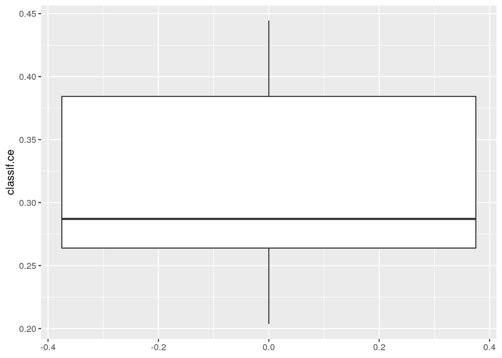

```r
autoplot(rr)
```

**Średni błąd z kroswalidacji**

```r
rr$aggregate(msr("classif.acc"))
```

```
## classif.acc
##   0.6851852
```

**Dokładność klasyfikacji na zbiorze testowym**

```r
acc <- (conf2.val['TP']+conf2.val['TN'])/sum(conf2.val)
acc
```

```
##        TP
## 0.6481481
```

Błąd uzyskanu na zbiorze testowym (który nie był wykorzystywany w kroswalidacji) jest zbliżony do średniego błędu z kroswalidacji, zatem teoretycznie możemy uznać model za dobrze przygotowany.

## 5. Podsumowanie

- Najlepsze rezultaty względem miar Accuracy i AUC otrzymano dla techniki imputacji polegającej zastąpieniu brakujących wartości, wartościami losowymi przy założeniu równego brawdopodobieństwa wylosowania każdej możliwej wartości.
- Wbrew intuicji technika polegająca na zastąpienie braków danych dominantami dała gorsze rezultaty niż wspomniane powyżej.
- Najgorsze rezultaty klasyfikacji względem rozważanych miar otrzymano dla zbioru z usuniętymi obserwacjami zawierającymi braki. Utrata blisko połowy obserwacji spowodowała, że algorytm dał względnie najgorsze wyniki, nawet w porównaniu z sytuacją utraty większości zmiennych objaśniających!.
- **Po przeprowadzeniu procesu kroswalidacji w większości przypadków średni błąd klasyfikacji na zbiorze testowym nie jest niższy niż początkowo**.
- Hierarchia wyników dla rozważanych technik imputacji względem wybranych miar:  
  pełna losowość > losowość warstwowa (random stratified) > usunięcie zmiennych objaśniających z brakami >>  
  >> zastąpienie braków dominantami >> usunięcie obserwacji zawierających braki

**UWAGA!** W przypadku technik opartych na danych imputowanych na drodze losowości dane po wylosowaniu zostały automatycznie przekonwertowane na typ character, należy zadbać o ponowną konwersję!

## 6. Ogólne wnioski

- Z punktu widzenia odpowiedniego działania algorytmu kluczowe jest właściwe zakodowanie zmiennych nominalnych i w razie potrzeby przeprowadzenie konwersji zmiennych.
- Każda technika imputacji to duża ingerencja w dane. Rozważone podstawowe modyfikacje powodują, że otrzymujemy inne klasyfikacje - inne są natury podziałów w drzewach decyzyjnych.
- Przy doborze metody imputacji, kluczowa jest znajomość struktury zbioru danych.
- Zabieg polegający na usunięciu obserwacji / atrybutów zawierających braki danych jest adekwatny tylko wówczas, gdy nie spowoduje utraty wielu informacji.
- Kroswalidacja jest kluczowa przy ocenie stabilności jakości modeli, ale **nie gwarantuje** większej dokładności klasyfikacji.